# AirBnB Price Prediction

This project utilizes the AirBnB Major Cities dataset acquired from: https://www.kaggle.com/datasets/rudymizrahi/airbnb-listings-in-major-us-cities-deloitte-ml

We will explore some important trends within the data and pick out important features for predicting a listing price. These prediction models are useful for a host looking to put up a new listing. The models suggest a listing price based on previous listings.

```python
import numpy as np
import pandas as pd
import matplotlib.pyplot as plt
import seaborn as sns

from sklearn.model_selection import train_test_split, cross_validate
from sklearn.linear_model import LinearRegression, Lasso
from sklearn.tree import DecisionTreeRegressor
from sklearn.ensemble import RandomForestRegressor
from sklearn.metrics import r2_score, mean_squared_error
from sklearn.svm import LinearSVR
```

Importing the data:

```python
data = pd.read_csv('data/train.csv')
data.head()
```

|  | id | log_price | property_type | room_type | amenities | accommodates | bathrooms | bed_type | cancellation_policy | cleaning_fee | ... | latitude | longitude | name | neighbourhood | number_of_reviews | review_scores_rating | thumbnail_url | zipcode | bedrooms | beds |
| --- | --- | --- | --- | --- | --- | --- | --- | --- | --- | --- | --- | --- | --- | --- | --- | --- | --- | --- | --- | --- | --- |
| 0 | 6901257 | 5.010635 | Apartment | Entire home/apt | {"Wireless Internet","Air conditioning",Kitche... | 3 | 1.0 | Real Bed | strict | True | ... | 40.696524 | -73.991617 | Beautiful brownstone 1-bedroom | Brooklyn Heights | 2 | 100.0 | https://a0.muscache.com/im/pictures/6d7cbbf7-c... | 11201 | 1.0 | 1.0 |
| 1 | 6304928 | 5.129899 | Apartment | Entire home/apt | {"Wireless Internet","Air conditioning",Kitche... | 7 | 1.0 | Real Bed | strict | True | ... | 40.766115 | -73.989040 | Superb 3BR Apt Located Near Times Square | Hell's Kitchen | 6 | 93.0 | https://a0.muscache.com/im/pictures/348a55fe-4... | 10019 | 3.0 | 3.0 |
| 2 | 7919400 | 4.976734 | Apartment | Entire home/apt | {TV,"Cable TV","Wireless Internet","Air condit... | 5 | 1.0 | Real Bed | moderate | True | ... | 40.808110 | -73.943756 | The Garden Oasis | Harlem | 10 | 92.0 | https://a0.muscache.com/im/pictures/6fae5362-9... | 10027 | 1.0 | 3.0 |
| 3 | 13418779 | 6.620073 | House | Entire home/apt | {TV,"Cable TV",Internet,"Wireless Internet",Ki... | 4 | 1.0 | Real Bed | flexible | True | ... | 37.772004 | -122.431619 | Beautiful Flat in the Heart of SF! | Lower Haight | 0 | NaN | https://a0.muscache.com/im/pictures/72208dad-9... | 94117.0 | 2.0 | 2.0 |
| 4 | 3808709 | 4.744932 | Apartment | Entire home/apt | {TV,Internet,"Wireless Internet","Air conditio... | 2 | 1.0 | Real Bed | moderate | True | ... | 38.925627 | -77.034596 | Great studio in midtown DC | Columbia Heights | 4 | 40.0 | NaN | 20009 | 0.0 | 1.0 |

5 rows × 29 columns

### Initial EDA

```python
data.shape
```

```
(74111, 29)
```

```python
# removed_columns = []
# for c in data.columns:
#     print(c)
#     if input() == 'y':
#             removed_columns.append(c)
```

Removing irrelevant features

```python
removed_columns = [
    'id',
    'description',
    'first_review',
    'last_review',
    'latitude',
    'longitude',
    'name',
    'number_of_reviews',
    'thumbnail_url',
    'review_scores_rating',
    'host_has_profile_pic',
    'host_identity_verified',
    'host_response_rate',
    'host_since',
    # 'zipcode'
    ]
data.drop(columns = removed_columns, inplace = True)
```

```python
data.columns
```

```
Index(['log_price', 'property_type', 'room_type', 'amenities', 'accommodates',
       'bathrooms', 'bed_type', 'cancellation_policy', 'cleaning_fee', 'city',
       'instant_bookable', 'neighbourhood', 'zipcode', 'bedrooms', 'beds'],
      dtype='object')
```

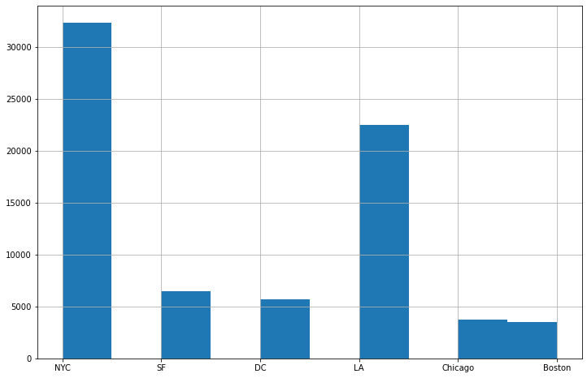

```python
plt.figure(figsize=(12,8))
data.city.hist()
plt.show()
```

Most listings are contained within NYC and LA. This is important to note when assessing prediction prices for other major cities. The model may hold biases for only being accurate with NYC and LA predictions.

```
<__array_function__ internals>:180: RuntimeWarning: Converting input from bool to <class 'numpy.uint8'> for compatibility.
```

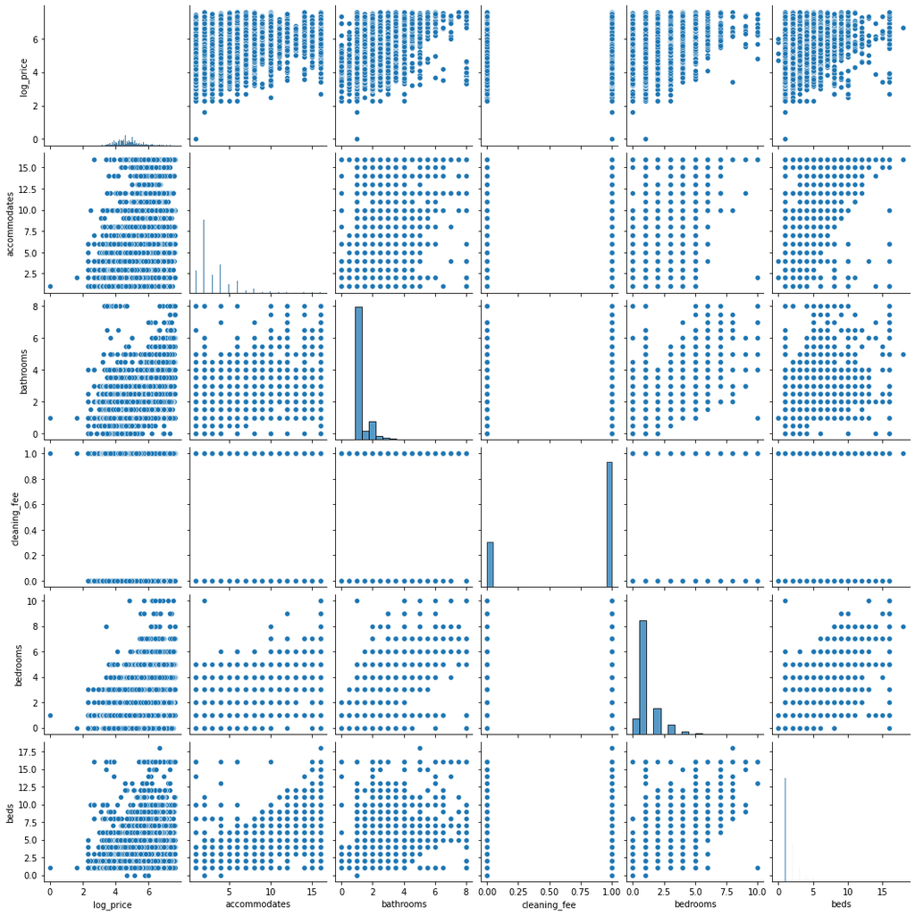

```python
sns.pairplot(data)
```

Our main focus should be on significant trends between log_price and other variables. We see that bedrooms and bathrooms both go up with price. The same is true for beds(bedspaces).

Next, we will see how listing prices vary by location. We will take median log_prices based on city and neighbourhood and assess how they're distibuted.

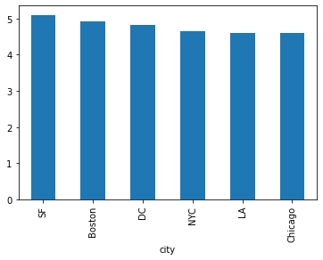

```python
data.groupby('city').median()['log_price'].sort_values(ascending=False).plot(kind='bar')
```

We see each major city has a small difference with each other when it comes to median price. SF has the greatest median price, while Chicago has the lowest.

```python
data[['city', 'neighbourhood', 'log_price']]
```

|  | city | neighbourhood | log_price |
| --- | --- | --- | --- |
| 0 | NYC | Brooklyn Heights | 5.010635 |
| 1 | NYC | Hell's Kitchen | 5.129899 |
| 2 | NYC | Harlem | 4.976734 |
| 3 | SF | Lower Haight | 6.620073 |
| 4 | DC | Columbia Heights | 4.744932 |
| ... | ... | ... | ... |
| 74106 | NYC | Williamsburg | 4.605170 |
| 74107 | LA | Hermosa Beach | 5.043425 |
| 74108 | NYC | Williamsburg | 5.220356 |
| 74109 | NYC | West Village | 5.273000 |
| 74110 | LA | Long Beach | 4.852030 |

74111 rows × 3 columns

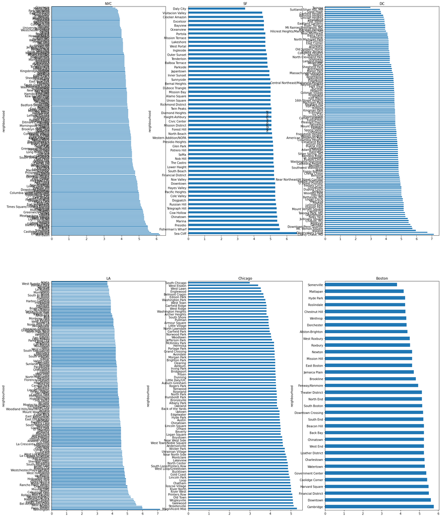

```python
neighbourhood_medians = data.groupby(['city', 'neighbourhood']).median()['log_price']
cities = data.city.unique()


for i, city in enumerate(cities, 1):
    # plt.figure(figsize=(12,8))
    plt.subplot(2, 3, i)
    neighbourhood_medians[city].sort_values(ascending=False).plot(kind='barh', figsize = (24, 32))
    plt.title(city)
plt.show()
```

```
) missing from current font.env/lib/python3.8/site-packages/IPython/core/pylabtools.py:151: UserWarning: Glyph 13 (
  fig.canvas.print_figure(bytes_io, **kw)
```

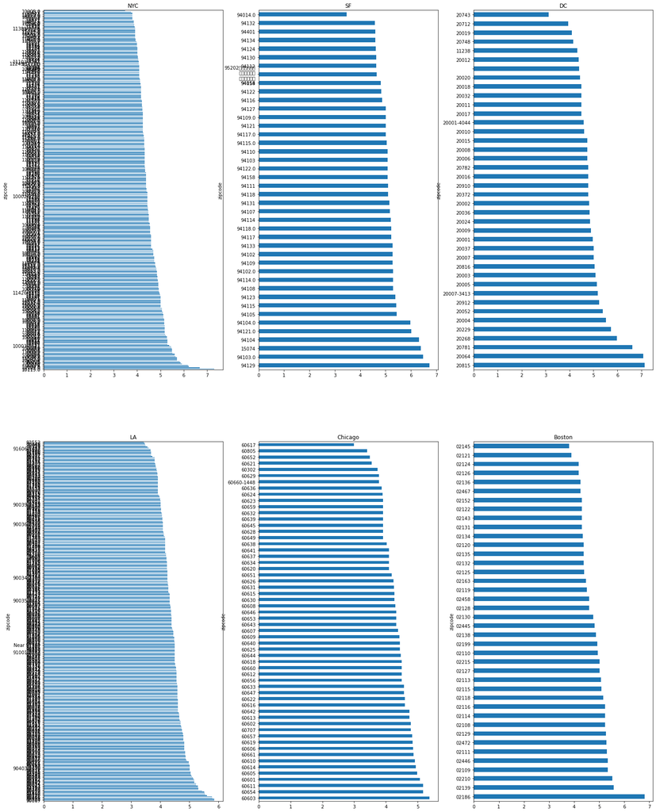

```python
zipcode_medians = data.groupby(['city', 'zipcode']).median()['log_price']
cities = data.city.unique()


for i, city in enumerate(cities, 1):
    # plt.figure(figsize=(12,8))
    plt.subplot(2, 3, i)
    zipcode_medians[city].sort_values(ascending=False).plot(kind='barh', figsize = (24, 32))
    plt.title(city)
plt.show()
```

Every city has its share of high and low median neighbourhoods.

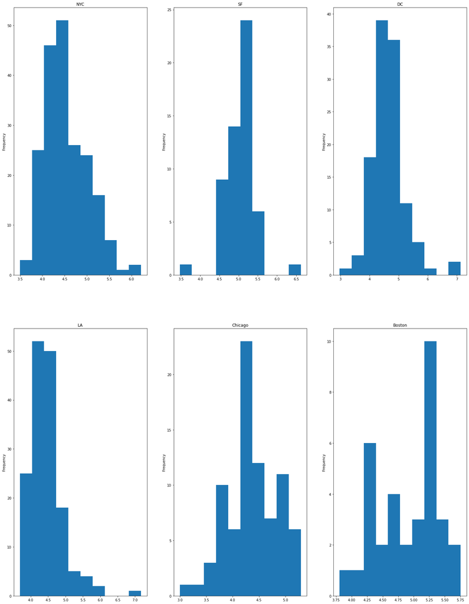

```python
neighbourhood_medians = data.groupby(['city', 'neighbourhood']).median()['log_price']
cities = data.city.unique()


for i, city in enumerate(cities, 1):
    plt.subplot(2, 3, i)
    neighbourhood_medians[city].plot(kind='hist', figsize = (24, 32))
    plt.title(city)
plt.show()
```

Each city has its own unique distribution for neighbourhood medians. This is an important consideration when modeling our price predictor.

Data Cleanup

```python
data.isna().mean()
```

```
log_price              0.000000
property_type          0.000000
room_type              0.000000
amenities              0.000000
accommodates           0.000000
bathrooms              0.002699
bed_type               0.000000
cancellation_policy    0.000000
cleaning_fee           0.000000
city                   0.000000
instant_bookable       0.000000
neighbourhood          0.092726
zipcode                0.013035
bedrooms               0.001228
beds                   0.001768
dtype: float64
```

```python
data[data['neighbourhood'] == "Hell's Kitchen"]['zipcode'].unique()
```

```
array(['10019', '10036', '10018', '10022', '10001', nan, '10017', '10026',
       '10013', '10000', '10014', '10003'], dtype=object)
```

Neighbourhood is the only feature with significant amount of missing values. Since a neighbourhood may contain multiple zipcodes(as shown above), it would be wiser to use zipcode as a predictor anyways. We can remove the neighbourhood column entirely and simply remove remaining samples with missing values.

```python
data.drop(columns='neighbourhood', inplace = True)
data.dropna(inplace = True)
```

```python
data.isna().mean()
```

```
log_price              0.0
property_type          0.0
room_type              0.0
amenities              0.0
accommodates           0.0
bathrooms              0.0
bed_type               0.0
cancellation_policy    0.0
cleaning_fee           0.0
city                   0.0
instant_bookable       0.0
zipcode                0.0
bedrooms               0.0
beds                   0.0
dtype: float64
```

```python
data.head()
```

|  | log_price | property_type | room_type | amenities | accommodates | bathrooms | bed_type | cancellation_policy | cleaning_fee | city | instant_bookable | zipcode | bedrooms | beds |
| --- | --- | --- | --- | --- | --- | --- | --- | --- | --- | --- | --- | --- | --- | --- |
| 0 | 5.010635 | Apartment | Entire home/apt | {"Wireless Internet","Air conditioning",Kitche... | 3 | 1.0 | Real Bed | strict | True | NYC | f | 11201 | 1.0 | 1.0 |
| 1 | 5.129899 | Apartment | Entire home/apt | {"Wireless Internet","Air conditioning",Kitche... | 7 | 1.0 | Real Bed | strict | True | NYC | t | 10019 | 3.0 | 3.0 |
| 2 | 4.976734 | Apartment | Entire home/apt | {TV,"Cable TV","Wireless Internet","Air condit... | 5 | 1.0 | Real Bed | moderate | True | NYC | t | 10027 | 1.0 | 3.0 |
| 3 | 6.620073 | House | Entire home/apt | {TV,"Cable TV",Internet,"Wireless Internet",Ki... | 4 | 1.0 | Real Bed | flexible | True | SF | f | 94117.0 | 2.0 | 2.0 |
| 4 | 4.744932 | Apartment | Entire home/apt | {TV,Internet,"Wireless Internet","Air conditio... | 2 | 1.0 | Real Bed | moderate | True | DC | t | 20009 | 0.0 | 1.0 |

Now the dataset is cleaned up.

### Feature Engineering

We'll first extract useful features from the amenities column. Each amenity will be encoded as its own feature. However, if all listings share a specific amenity, it won't be useful as a feature. The same may be true if most listings share the same amenity. Thus, we will encode all amenities and extract only the significant ones to use as predctors for our model.

```python
data['amenities'][121]
```

```
'{Internet,"Wireless Internet",Kitchen,"Free parking on premises",Heating,"Family/kid friendly","Hair dryer",Iron,"translation missing: en.hosting_amenity_50"}'
```

```python
data['amenities'] = data['amenities'].str.replace('"', '').str.replace('{', '').str.replace('}', '')
```

```python
amenities_set = set()
for amenities in data['amenities']:
    amenities_list = amenities.split(',')
    amenities_set = amenities_set.union(set(amenities_list))
```

```python
amenities_set
```

```
{'',
 ' smooth pathway to front door',
 '24-hour check-in',
 'Accessible-height bed',
 'Accessible-height toilet',
 'Air conditioning',
 'Air purifier',
 'BBQ grill',
 'Baby bath',
 'Baby monitor',
 'Babysitter recommendations',
 'Bath towel',
 'Bathtub',
 'Bathtub with shower chair',
 'Beach essentials',
 'Beachfront',
 'Bed linens',
 'Body soap',
 'Breakfast',
 'Buzzer/wireless intercom',
 'Cable TV',
 'Carbon monoxide detector',
 'Cat(s)',
 'Changing table',
 'Children’s books and toys',
 'Children’s dinnerware',
 'Cleaning before checkout',
 'Coffee maker',
 'Cooking basics',
 'Crib',
 'Disabled parking spot',
 'Dishes and silverware',
 'Dishwasher',
 'Dog(s)',
 'Doorman',
 'Doorman Entry',
 'Dryer',
 'EV charger',
 'Elevator',
 'Elevator in building',
```

[output cut: 76 more lines]

```
 'Washer',
 'Washer / Dryer',
 'Waterfront',
 'Well-lit path to entrance',
 'Wheelchair accessible',
 'Wide clearance to bed',
 'Wide clearance to shower & toilet',
 'Wide clearance to shower and toilet',
 'Wide doorway',
 'Wide entryway',
 'Wide hallway clearance',
 'Window guards',
 'Wireless Internet',
 'translation missing: en.hosting_amenity_49',
 'translation missing: en.hosting_amenity_50'}
```

Some amenities contain duplicates(different spelling) or are meaningless. We will remove those meaningless titles and clean up duplicates.

```python
removed_amenities = set([
    '',
    'translation missing: en.hosting_amenity_49',
    'translation missing: en.hosting_amenity_50',
    'Wide clearance to shower & toilet'
])
amenities_set -= removed_amenities
```

```python
data['amenities'] = data['amenities'].str.replace('&', 'and')
```

```python
# initializing amenity df to encode
amenities_df = pd.DataFrame(columns=amenities_set, data = [[0 for _ in range(len(amenities_set))] for i in range(data.shape[0])])
amenities_df.head()
```

|  | Wide doorway | Internet | Table corner guards | Buzzer/wireless intercom | Gym | Private entrance | Safety card | Ethernet connection | Smart lock | Keypad | ... | Indoor fireplace | Hot tub | Suitable for events | Doorman | Baby monitor | Toilet paper | Air conditioning | Outlet covers | Pocket wifi | Lake access |
| --- | --- | --- | --- | --- | --- | --- | --- | --- | --- | --- | --- | --- | --- | --- | --- | --- | --- | --- | --- | --- | --- |
| 0 | 0 | 0 | 0 | 0 | 0 | 0 | 0 | 0 | 0 | 0 | ... | 0 | 0 | 0 | 0 | 0 | 0 | 0 | 0 | 0 | 0 |
| 1 | 0 | 0 | 0 | 0 | 0 | 0 | 0 | 0 | 0 | 0 | ... | 0 | 0 | 0 | 0 | 0 | 0 | 0 | 0 | 0 | 0 |
| 2 | 0 | 0 | 0 | 0 | 0 | 0 | 0 | 0 | 0 | 0 | ... | 0 | 0 | 0 | 0 | 0 | 0 | 0 | 0 | 0 | 0 |
| 3 | 0 | 0 | 0 | 0 | 0 | 0 | 0 | 0 | 0 | 0 | ... | 0 | 0 | 0 | 0 | 0 | 0 | 0 | 0 | 0 | 0 |
| 4 | 0 | 0 | 0 | 0 | 0 | 0 | 0 | 0 | 0 | 0 | ... | 0 | 0 | 0 | 0 | 0 | 0 | 0 | 0 | 0 | 0 |

5 rows × 127 columns

```python
for i, amenities in enumerate(data['amenities']):
    amenities_list = amenities.split(',')
    for amenity in amenities_list:
        amenities_df.loc[i][amenity] = 1
```

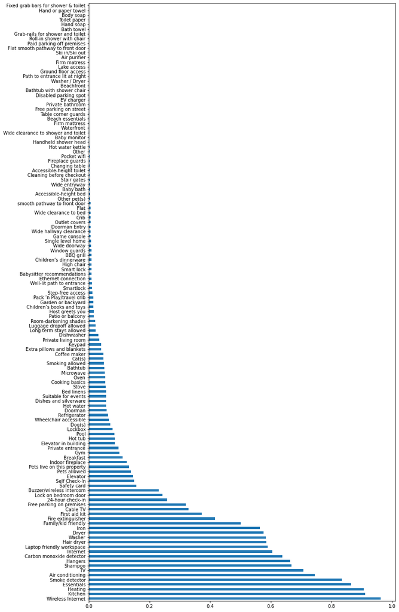

```python
amenities_df.mean().sort_values(ascending = False).plot(kind = 'barh', figsize=(12, 24))
```

```python
sum(amenities_df.mean() <= .01)
```

```
59
```

```python
sum(amenities_df.mean() >= .80)
```

```
5
```

59 amenities are only offered by less than 1% of the listings, while 5 amenities are offered by at least 80% of listings. For now, we'll keep all amenities and let the model decide which amenities should be weighed less/higher.

Moving forward, we'll do a quick cleanup on zipcode to make sure they're only 5 digits.

```python
data['zipcode'].nunique()
```

```
769
```

```python
data['zipcode'].apply(lambda x: x[:5]).nunique()
```

```
653
```

Some zipcodes had an extra '.0' and we can see that filtering out the extra part reduced the total unique zipcodes from 769 to 653.

```python
data['zipcode'] = data['zipcode'].apply(lambda x: x[:5])
```

The remaining categorical features can simply be dummy encoded and we're ready to train some models!

```python
data.drop(columns = 'amenities', inplace = True)
```

```python
encoded = pd.get_dummies(data)
encoded
```

|  | log_price | accommodates | bathrooms | cleaning_fee | bedrooms | beds | property_type_Apartment | property_type_Bed & Breakfast | property_type_Boat | property_type_Boutique hotel | ... | zipcode_94130 | zipcode_94131 | zipcode_94132 | zipcode_94133 | zipcode_94134 | zipcode_94158 | zipcode_94401 | zipcode_95202 | zipcode_99135 | zipcode_Near |
| --- | --- | --- | --- | --- | --- | --- | --- | --- | --- | --- | --- | --- | --- | --- | --- | --- | --- | --- | --- | --- | --- |
| 0 | 5.010635 | 3 | 1.0 | True | 1.0 | 1.0 | 1 | 0 | 0 | 0 | ... | 0 | 0 | 0 | 0 | 0 | 0 | 0 | 0 | 0 | 0 |
| 1 | 5.129899 | 7 | 1.0 | True | 3.0 | 3.0 | 1 | 0 | 0 | 0 | ... | 0 | 0 | 0 | 0 | 0 | 0 | 0 | 0 | 0 | 0 |
| 2 | 4.976734 | 5 | 1.0 | True | 1.0 | 3.0 | 1 | 0 | 0 | 0 | ... | 0 | 0 | 0 | 0 | 0 | 0 | 0 | 0 | 0 | 0 |
| 3 | 6.620073 | 4 | 1.0 | True | 2.0 | 2.0 | 0 | 0 | 0 | 0 | ... | 0 | 0 | 0 | 0 | 0 | 0 | 0 | 0 | 0 | 0 |
| 4 | 4.744932 | 2 | 1.0 | True | 0.0 | 1.0 | 1 | 0 | 0 | 0 | ... | 0 | 0 | 0 | 0 | 0 | 0 | 0 | 0 | 0 | 0 |
| ... | ... | ... | ... | ... | ... | ... | ... | ... | ... | ... | ... | ... | ... | ... | ... | ... | ... | ... | ... | ... | ... |
| 74106 | 4.605170 | 1 | 1.0 | False | 1.0 | 1.0 | 1 | 0 | 0 | 0 | ... | 0 | 0 | 0 | 0 | 0 | 0 | 0 | 0 | 0 | 0 |
| 74107 | 5.043425 | 4 | 2.0 | True | 2.0 | 4.0 | 1 | 0 | 0 | 0 | ... | 0 | 0 | 0 | 0 | 0 | 0 | 0 | 0 | 0 | 0 |
| 74108 | 5.220356 | 5 | 1.0 | True | 2.0 | 2.0 | 1 | 0 | 0 | 0 | ... | 0 | 0 | 0 | 0 | 0 | 0 | 0 | 0 | 0 | 0 |
| 74109 | 5.273000 | 2 | 1.0 | True | 0.0 | 2.0 | 1 | 0 | 0 | 0 | ... | 0 | 0 | 0 | 0 | 0 | 0 | 0 | 0 | 0 | 0 |
| 74110 | 4.852030 | 4 | 1.0 | False | 1.0 | 2.0 | 0 | 0 | 1 | 0 | ... | 0 | 0 | 0 | 0 | 0 | 0 | 0 | 0 | 0 | 0 |

72815 rows × 714 columns

```python
encoded.index = amenities_df.index
```

```python
data = pd.concat([encoded, amenities_df], axis=1).drop_duplicates()
data.head()
```

|  | log_price | accommodates | bathrooms | cleaning_fee | bedrooms | beds | property_type_Apartment | property_type_Bed & Breakfast | property_type_Boat | property_type_Boutique hotel | ... | Indoor fireplace | Hot tub | Suitable for events | Doorman | Baby monitor | Toilet paper | Air conditioning | Outlet covers | Pocket wifi | Lake access |
| --- | --- | --- | --- | --- | --- | --- | --- | --- | --- | --- | --- | --- | --- | --- | --- | --- | --- | --- | --- | --- | --- |
| 0 | 5.010635 | 3 | 1.0 | True | 1.0 | 1.0 | 1 | 0 | 0 | 0 | ... | 0 | 0 | 0 | 0 | 0 | 0 | 1 | 0 | 0 | 0 |
| 1 | 5.129899 | 7 | 1.0 | True | 3.0 | 3.0 | 1 | 0 | 0 | 0 | ... | 0 | 0 | 0 | 0 | 0 | 0 | 1 | 0 | 0 | 0 |
| 2 | 4.976734 | 5 | 1.0 | True | 1.0 | 3.0 | 1 | 0 | 0 | 0 | ... | 0 | 0 | 0 | 0 | 0 | 0 | 1 | 0 | 0 | 0 |
| 3 | 6.620073 | 4 | 1.0 | True | 2.0 | 2.0 | 0 | 0 | 0 | 0 | ... | 1 | 0 | 0 | 0 | 0 | 0 | 0 | 0 | 0 | 0 |
| 4 | 4.744932 | 2 | 1.0 | True | 0.0 | 1.0 | 1 | 0 | 0 | 0 | ... | 0 | 0 | 0 | 0 | 0 | 0 | 1 | 0 | 0 | 0 |

5 rows × 841 columns

```python
data.shape
```

```
(72534, 841)
```

The dataset is now fully cleaned and preprocessed.

### Data Splitting

```python
X = data.drop(columns='log_price')
y = data['log_price']

X_train, X_test, y_train, y_test = train_test_split(X, y, test_size=0.3, random_state=42)
```

### Model Fitting

We'll be experimenting with a few models to see which one fits best with this data. For this assignment, we'll use:

- Linear Regression
- Decision Tree
- Random Forest
- SVM

#### Linear Regression

We'll start with a simple linear regression experiment to see how well it model performs. I originally decided not to try this algorithm out since I figured it'd be too simple. However, it will help assess whether the extracted features truly carry a linear relationship with the listing price.

```python
lr = LinearRegression()

lr.fit(X_train, y_train)
train_pred = lr.predict(X_train)
test_pred = lr.predict(X_test)

r2_scores = [r2_score(y_train, train_pred), r2_score(y_test, test_pred)]
mse_scores = [mean_squared_error(y_train, train_pred), mean_squared_error(y_test, test_pred)]

lr_scores = {
    'R2' : r2_scores,
    'MSE' : mse_scores
}
```

```python
pd.DataFrame(data = lr_scores, index = ['Train', 'Test'])
```

|  | R2 | MSE |
| --- | --- | --- |
| Train | 6.820546e-01 | 1.624673e-01 |
| Test | -5.145239e+19 | 2.655649e+19 |

Linear Regression is clearly not an optimal model to use as a predictor here.

#### Decision Tree

We'll start our series of experiments with a simple tree, tuning its depth with 5-fold cv.

```python
depth_results = dict()

maxTreeDepth = list(range(1, 16))

for depth in maxTreeDepth:
    cv_results = cross_validate(DecisionTreeRegressor(max_depth = depth), X_train, y_train, cv = 5, scoring=('r2', 'neg_mean_squared_error'), return_train_score=True, return_estimator=True)
    depth_results[depth] = cv_results
```

```python
r2_results = dict()
mse_results = dict()

for depth in maxTreeDepth:
    r2_results[depth] = [depth_results[depth]['train_r2'].mean(), depth_results[depth]['test_r2'].mean()]
    mse_results[depth] = [depth_results[depth]['train_neg_mean_squared_error'].mean(), depth_results[depth]['test_neg_mean_squared_error'].mean()]
```

```python
r2_results = pd.DataFrame(r2_results)
mse_results = pd.DataFrame(mse_results)
```

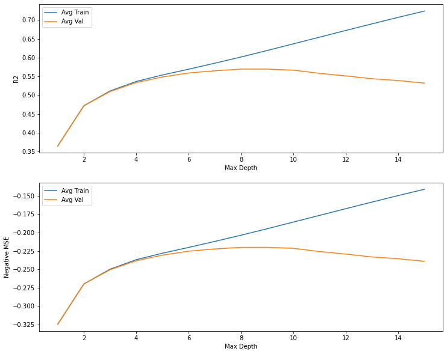

```python
plt.figure(figsize=(12,10))

plt.subplot(2,1,1)
plt.plot(r2_results.loc[0], label = 'Avg Train')
plt.plot(r2_results.loc[1], label = 'Avg Val')
plt.xlabel('Max Depth')
plt.ylabel('R2')
plt.legend()


plt.subplot(2,1,2)
plt.plot(mse_results.loc[0], label = 'Avg Train')
plt.plot(mse_results.loc[1], label = 'Avg Val')
plt.xlabel('Max Depth')
plt.ylabel('Negative MSE')
plt.legend()
plt.show()
```

Depth of 8 appears to be the sweet spot for this learning model. Any depth beyond that shows strong evidence of overfitting.

Fitting and evaluating tree w/ depth = 8 on entire training set.

```python
tree = DecisionTreeRegressor(max_depth = 8)
tree.fit(X_train, y_train)
tree.score(X_test, y_test)
```

```
0.5692574127752942
```

#### Random Forest

We'll be tuning a random forest's number of trees.

```python
depth_results = dict()

tree_values = list(range(1, 51, 5))

for depth in tree_values:
    cv_results = cross_validate(RandomForestRegressor(n_estimators=depth), X_train, y_train, cv = 5, scoring=('r2', 'neg_mean_squared_error'), return_train_score=True)
    depth_results[depth] = cv_results
```

```python
r2_results = dict()
mse_results = dict()

for depth in tree_values:
    if depth == 51: break
    r2_results[depth] = [depth_results[depth]['train_r2'].mean(), depth_results[depth]['test_r2'].mean()]
    mse_results[depth] = [depth_results[depth]['train_neg_mean_squared_error'].mean(), depth_results[depth]['test_neg_mean_squared_error'].mean()]
```

```python
r2_results = pd.DataFrame(r2_results)
mse_results = pd.DataFrame(mse_results)
```

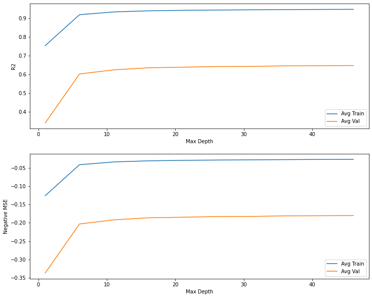

```python
plt.figure(figsize=(12,10))

plt.subplot(2,1,1)
plt.plot(r2_results.loc[0], label = 'Avg Train')
plt.plot(r2_results.loc[1], label = 'Avg Val')
plt.xlabel('Max Depth')
plt.ylabel('R2')
plt.legend()


plt.subplot(2,1,2)
plt.plot(mse_results.loc[0], label = 'Avg Train')
plt.plot(mse_results.loc[1], label = 'Avg Val')
plt.xlabel('Max Depth')
plt.ylabel('Negative MSE')
plt.legend()
plt.show()
```

The forest begins to plateu in performance at around 16 trees.

```python
tree = RandomForestRegressor(n_estimators=16)
tree.fit(X_train, y_train)
tree.score(X_test, y_test)
```

```
0.6383219474818176
```

So far the forest with 16 trees is the best model.

#### SVM

```python
svm = LinearSVR()

svm.fit(X_train, y_train)
train_pred = svm.predict(X_train)
test_pred = svm.predict(X_test)

r2_scores = [r2_score(y_train, train_pred), r2_score(y_test, test_pred)]
mse_scores = [mean_squared_error(y_train, train_pred), mean_squared_error(y_test, test_pred)]

svm_scores = {
    'R2' : r2_scores,
    'MSE' : mse_scores
}
```

```python
pd.DataFrame(data = svm_scores, index = ['Train', 'Test'])
```

|  | R2 | MSE |
| --- | --- | --- |
| Train | 0.672913 | 0.167138 |
| Test | 0.658701 | 0.176157 |

SVM Performs best with a test R2 of 0.66! This model also avoids bias scores unlike the tree models.

### Conclusion

Perhaps with a more complext model, we'll be able to improve the performance(Neural Net). On the other hand, the final dataset may be missing important features for a better predictor.